# Where Does the Money Go?

A Decade of Medicare Spending

[figure not shown]

CMS Geographic Variation Data · 2014-2024 Authors: Tom Tran Nguyen and Ariana Lewis

# Where Does the Money Go?

A decade of Medicare spending - who gets it, where it goes, and how the map has changed.

Every year, Medicare writes checks totaling hundreds of billions of dollars to hospitals, nursing homes, home health agencies, surgeons, and ambulances. It covers about one in five Americans and accounts for a fifth of all U.S. healthcare spending. But the way that money gets divided up is not fixed. This is that story.

Total Spending

## The bill keeps growing.

In 2014, Medicare spent about **$9,767 per beneficiary**. By 2024, that number was **$13,606**, a **39%** jump in ten years. It happened even as policymakers were actively trying to slow it down.

COVID Effect

## 2020 was an outlier, not a turning point.

One exception was the year of the COVID pandemic, 2020. Procedures were cancelled, offices were closed, and people avoided hospitals even when they probably shouldn’t have. Spending dropped. Then it snapped back the following year harder than it ever had.

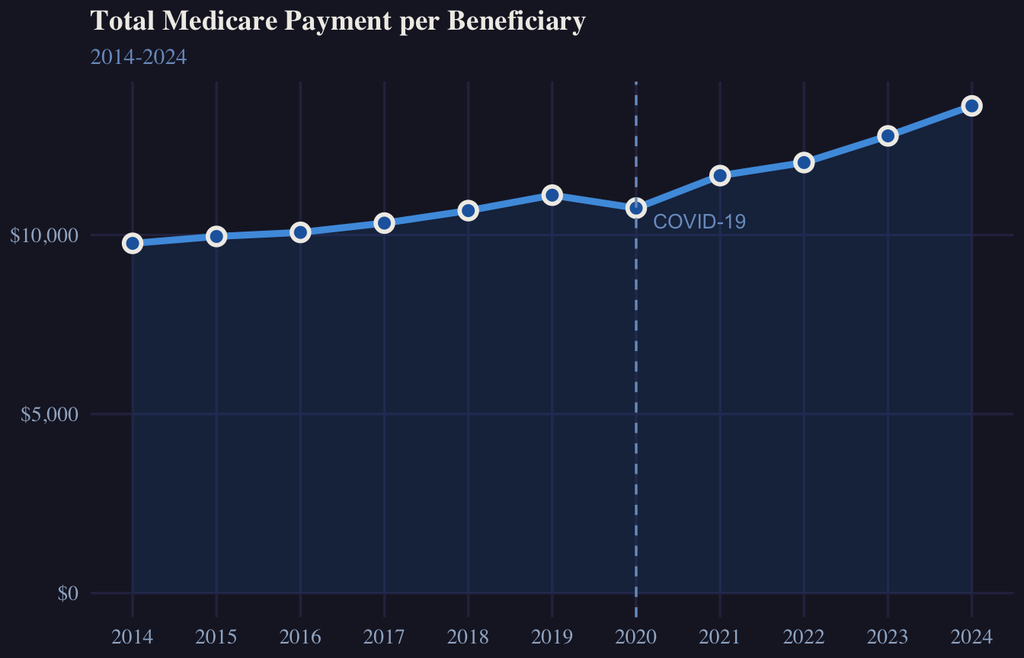

Spending Mix

## Inpatient care is shrinking — slowly, but consistently.

In 2014, inpatient hospital care accounted for **33 cents of every Medicare dollar**. By 2024 it had fallen to **28 cents**. That may not sound dramatic, but in a program spending hundreds of billions of dollars each year, a five-point shift represents a massive redistribution of resources. The trend reflects a broader transformation in how care is delivered. Services that once required a hospital stay are increasingly being performed in outpatient settings.

The Winner

## Outpatient care keeps taking share.

While inpatient spending has steadily declined, outpatient care has moved in the opposite direction. Its share grew from **13.5%** in 2014 to **18.8%** in 2024, making it one of the fastest-growing components of Medicare spending. These changes reflect years of payment reform and policy incentives designed to shift care away from hospitals and toward lower-cost settings. Since the Affordable Care Act, Medicare has increasingly rewarded outpatient treatment and penalized avoidable inpatient utilization.

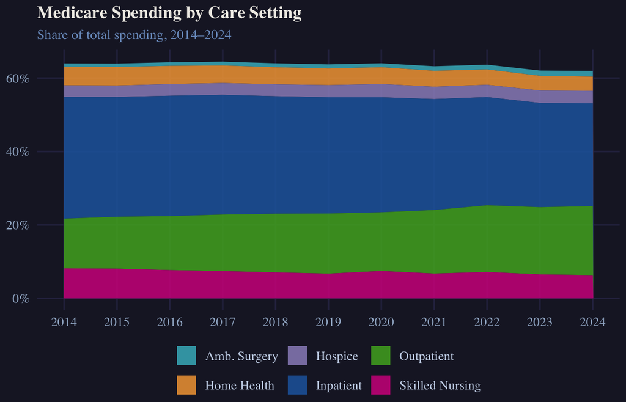

By Service Type

## Each setting has its own trajectory.

Looking only at total spending can hide important differences between care settings. When each service is viewed separately, the patterns become much clearer. Some categories are steadily gaining share, others are clearly declining, and a few show volatile, unpredictable patterns.

Nothing Is Standing Still

## Every setting is in motion.

None of them are standing still. Medicare spending is constantly being reshaped as technology, provider behavior, and payment policy influence where and how care is delivered.

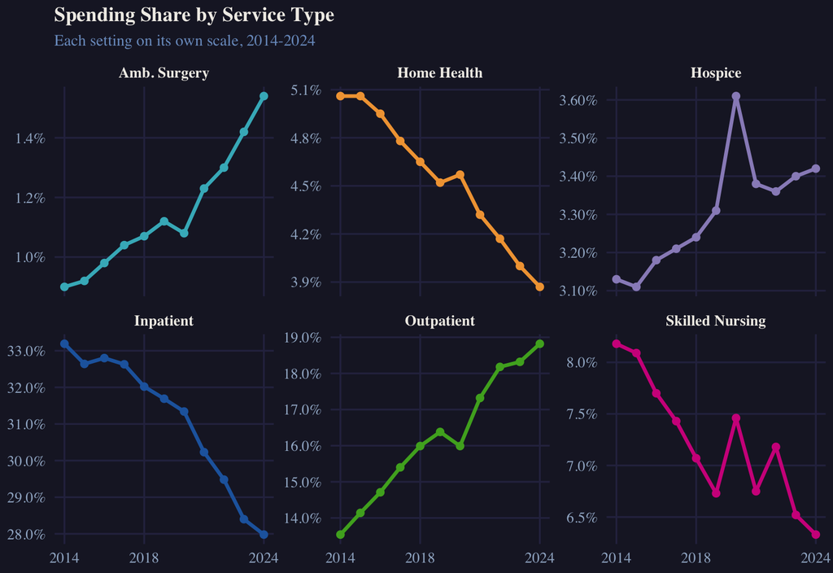

2024 Snapshot

## Where every dollar went in 2024.

Even after a decade of change, **inpatient** care remains the largest single component of Medicare spending. Outpatient services now account for nearly **19 cents of every Medicare dollar**, not far behind inpatient care, which still leads at **28 cents**.

The Rest

## Every other setting plays a smaller role.

Skilled nursing facilities have been reduced to roughly **six cents of every Medicare dollar**. Home health and hospice together account for **less than eight percent** of spending, while ambulatory surgery centers continue to grow from a small base.

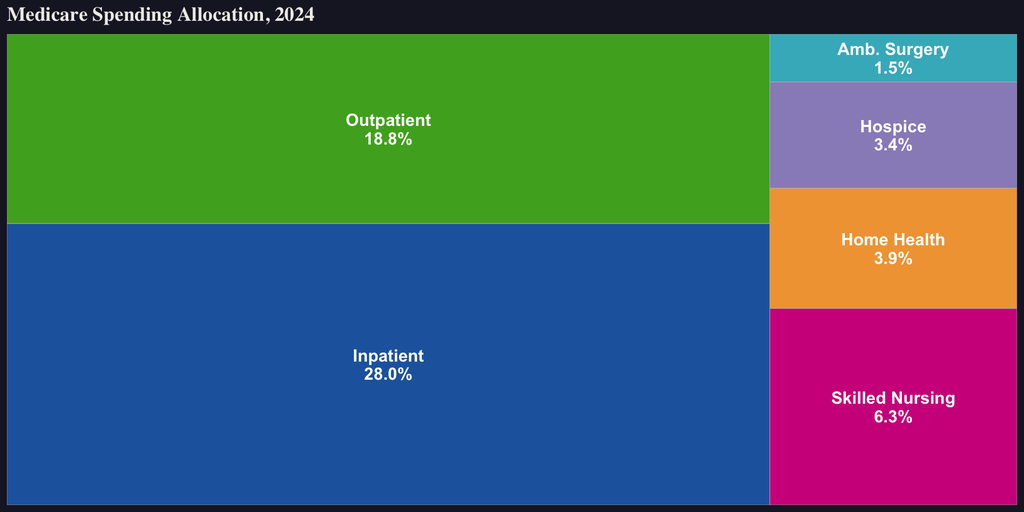

Geography

## Where you live determines what Medicare spends on you.

Medicare is a national program, but spending patterns differ depending on what state you live in. A beneficiary in Minnesota costs the program much less than a beneficiary in Louisiana or New Jersey, even after we adjust for differences in local healthcare prices.

More Care, Not Better Care

## Higher spending doesn’t mean better outcomes.

These gaps are not the result of one population being healthier than another. The differences are how healthcare is delivered. How often patients are admitted, which services are utilized, and how providers respond to local medical culture and incentives.

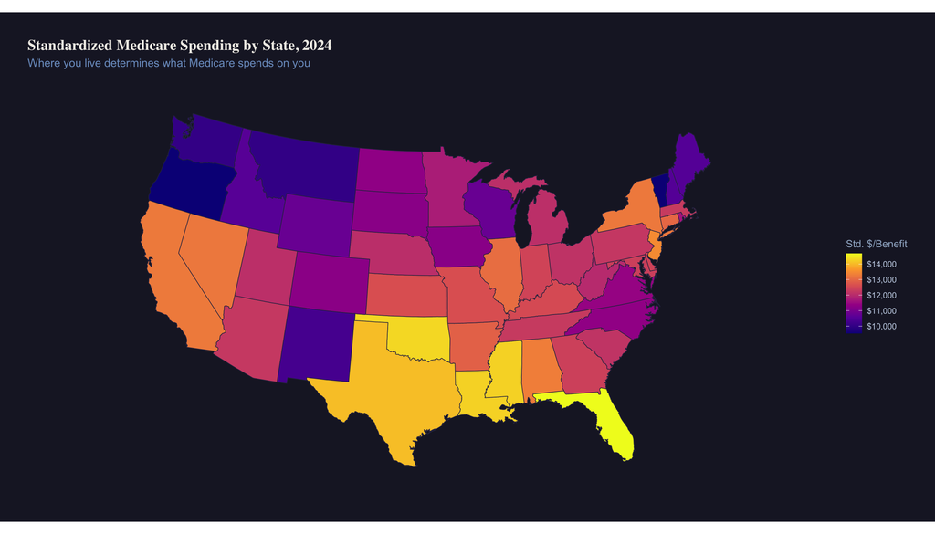

State Trends Over Time

## The geography of spending hasn’t changed much in a decade.

Some states have always cost more. The choropleth showed you where spending lands in 2024. This shows you that the pattern isn’t new. **Florida, Louisiana, and Texas** have sat at the top of Medicare spending for the entire decade, not because of a single bad year, but because of something **structural** about how care is delivered there.

The Other End

## Some states have always spent less.

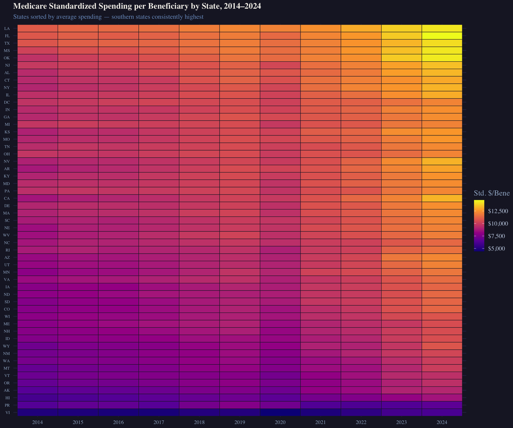

State Comparison

## The inpatient-to-outpatient shift isn’t even.

While Medicare has been moving away from inpatient care, the pace of that transition differs from state to state. Some regions have started to use outpatient delivery models more frequently, while others continue to rely on traditional hospital-based care. These differences help explain why spending levels vary across the country.

Reading the Bubbles

## Size reveals total cost.

In the chart, each bubble represents a state. Position shows the balance between inpatient and outpatient spending. Bubble size reflects total Medicare spending per beneficiary. This reveals which states are both high spending and heavily reliant on hospitals.

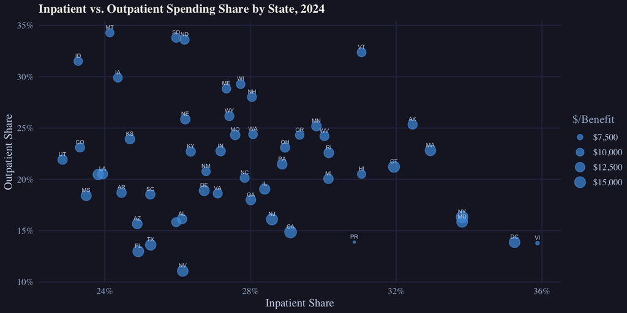

Per-User Cost

## Aggregate shares can be misleading.

A service may account for a small portion of overall spending simply because few beneficiaries use it, not because it is inexpensive. When viewed per user, the cost differences between settings become much more dramatic.

The Standout

## One admission costs more than dozens of outpatient visits.

Inpatient care stands out immediately. In practical terms, **one avoided hospital admission can offset the cost of dozens of outpatient visits**. That is why efforts to reduce unnecessary admissions remain one of the most powerful tools for controlling healthcare spending.

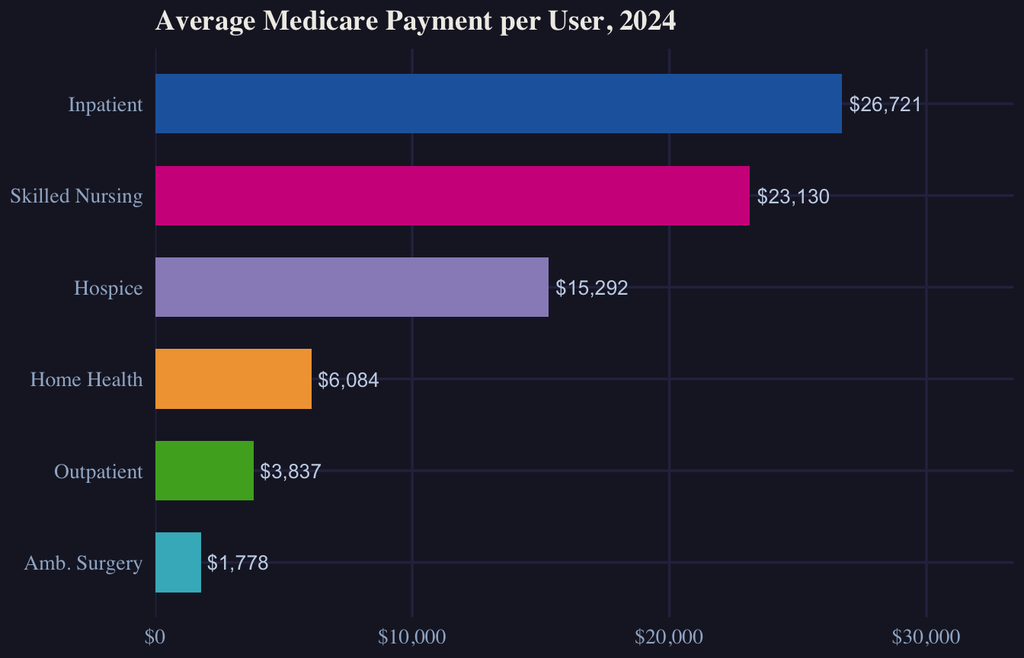

Spending Distribution

## The gap between states is widening.

While Medicare spending increased nationwide, the distribution of state level spending became more dispersed. In 2014, most states were clustered within a narrow range of spending levels.

Spreading Apart

## By 2024, the spread had grown.

By 2024, spending shifted upward and spread across a wider range. This indicates larger differences in Medicare spending between states. Where beneficiaries live continues to play a significant role in how much care costs the program.

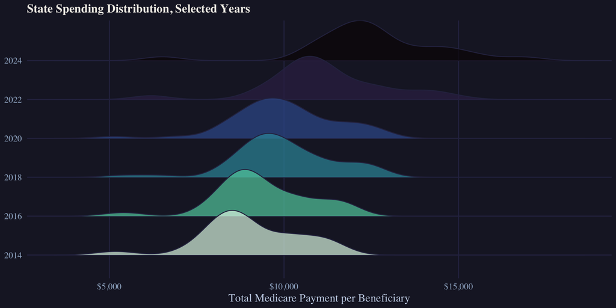

Emergency Room

## High ER use is a system efficiency problem.

States with high emergency room utilization rates do not simply spend more on emergency services, they often spend more across the healthcare system as a whole. High ER use signals barriers to primary care, limited access to preventive services, or inefficiencies in care coordination.

A Useful Indicator

## ER rates signal something deeper.

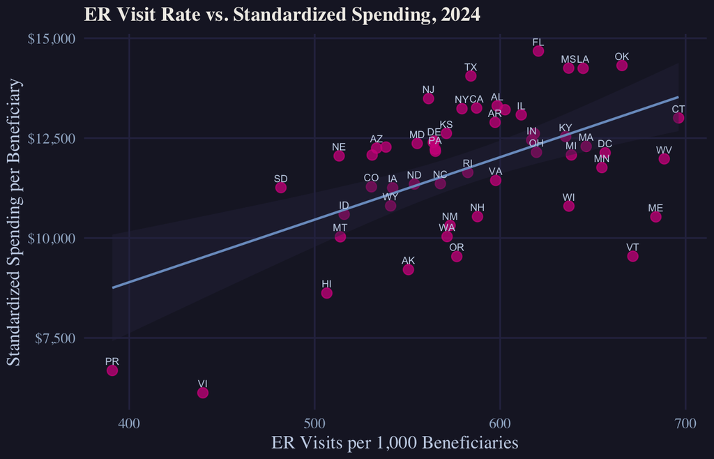

Readmissions

## Coming back too soon.

Readmissions are costly for both patients and Medicare. In many cases, they’re viewed as indicators of gaps in care coordination, discharge planning, or follow-up treatment. The gap between the best and worst performing states is substantial.

Policy Response

## Penalties have helped, but progress is uneven.

Since 2012, Medicare’s Hospital Readmissions Reduction Program imposed financial penalties on hospitals with excessive readmission rates. Nationally, the policy has helped reduce the frequency of readmission, but progress hasn’t been uniform across the country.

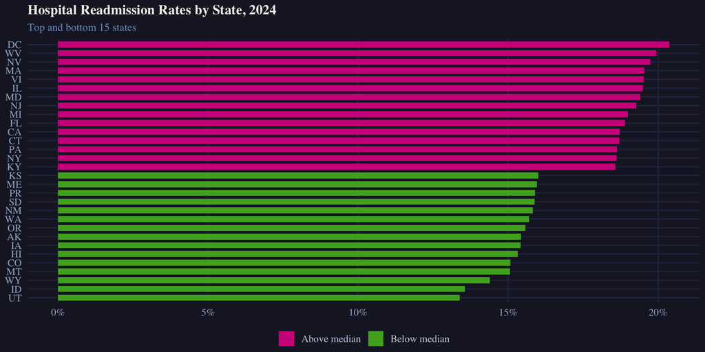

Conclusion

# What It All Adds Up To

A decade of Medicare spending reveals not just rising costs, but a healthcare system that is steadily changing how care is delivered.

Some of these changes reflect genuine progress. Advances in medical technology allow procedures that once required days in a hospital to be completed in a matter of hours. Better coordination, stronger payment incentives, and improved care management have helped reduce unnecessary admissions and shift treatment into lower-cost settings.

Yet the data also shows that cost growth has not disappeared. Spending continues to rise, and significant differences remain between states. Geography, utilization patterns, and local healthcare systems still play a major role in determining how much Medicare ultimately pays for care.

For actuaries and healthcare analysts, these trends influence pricing models, reserve calculations, risk forecasts, and long-term projections of healthcare spending.

CMS Geographic Variation Public Use File (2014-2024)